# ZIP R Source Code Analysis

# Prep

## Download and Install Required Packages

Install and load necessary packages

```r
required_pkgs <- c(
    "drc",
    "reshape2",
    "compiler",
    "truncnorm",
    "data.table"
)
if (!require(required_pkgs, quietly = TRUE))
    install.packages(setdiff(required_pkgs, rownames(installed.packages())))
```

## Download the Mathews Griner Drug Combination Screening Dataset

```r
## Data directory
if (!dir.exists("../data"))
    dir.create(path = "../data")

## Download dataset
if (!file.exists("../data/Griner_et_al.zip")) {
    utils::download.file(
        url = "https://ars.els-cdn.com/content/image/1-s2.0-S2001037015000422-mmc4.zip",
        method = "wget",
        destfile = "../data/Griner_et_al.zip"
    )
}

if (!all(file.exists(
    c("../data/metadata.csv",
      "../data/responses.csv")
    ))) {
    utils::unzip(
        zipfile = "../data/Griner_et_al.zip",
        files = c("metadata.csv", "responses.csv"), ## extract dataset files only
        exdir = "../data"
    )
}
```

## Load Required Packages and Data

```r
library(drc)
library(caTools)
library(reshape2)
library(compiler)
library(truncnorm)
library(data.table)
# Read response and metadata
response <- fread("../data/responses.csv")
metadata <- fread("../data/metadata.csv")

# get unique block ids
# 36 rows per block ID, 6 x 6 experiment
blockId <- unique(response$BlockId)
```

Preview for the experiment metadata

| AssayId | BlockId | Size | QCScore | RowSid | RowName | RowTarget | ColSid | ColName | ColTarget | RowIC50 | ColIC50 | RowConcs | ColConcs | RowConcUnit | ColConcUnit |
| --- | --- | --- | --- | --- | --- | --- | --- | --- | --- | --- | --- | --- | --- | --- | --- |
| 241 | 1 | 6 | null | NCGC00181170-01 | Bendamustine | Antimetabolite | NCGC00187912 | PCI-32765 | Btk/Lck/Lyn inhibitor | 0 | 0 | 1250.0,312.5,78.125,19.5313,4.8828,0.0 | 25.0,6.25,1.5625,0.3906,0.0977,0.0 | uM | uM |
| 241 | 2 | 6 | null | NCGC00015609-06 | Lonidamine | hexokinase inactivator | NCGC00187912 | PCI-32765 | Btk/Lck/Lyn inhibitor | 0 | 0 | 1250.0,312.5,78.125,19.5313,4.8828,0.0 | 25.0,6.25,1.5625,0.3906,0.0977,0.0 | uM | uM |
| 241 | 3 | 6 | null | NCGC00167491-03 | Lenalidomide | TNF-alpha Production Inhibitor | NCGC00187912 | PCI-32765 | Btk/Lck/Lyn inhibitor | 0 | 0 | 1250.0,312.5,78.125,19.5313,4.8828,0.0 | 25.0,6.25,1.5625,0.3906,0.0977,0.0 | uM | uM |
| 241 | 4 | 6 | null | NCGC00022567-06 | Cladribine | Adenosine Deaminase Inhibitor | NCGC00187912 | PCI-32765 | Btk/Lck/Lyn inhibitor | 0 | 0 | 1250.0,312.5,78.125,19.5313,4.8828,0.0 | 25.0,6.25,1.5625,0.3906,0.0977,0.0 | uM | uM |
| 241 | 5 | 6 | null | NCGC00182045-02 | Pentostatin | Adenosine Deaminase Inhibitor | NCGC00187912 | PCI-32765 | Btk/Lck/Lyn inhibitor | 0 | 0 | 1250.0,312.5,78.125,19.5313,4.8828,0.0 | 25.0,6.25,1.5625,0.3906,0.0977,0.0 | uM | uM |
| 241 | 6 | 6 | null | NCGC00091641-03 | 6-mercaptopurine | Purine Antagonist | NCGC00187912 | PCI-32765 | Btk/Lck/Lyn inhibitor | 0 | 0 | 1250.0,312.5,78.125,19.5313,4.8828,0.0 | 25.0,6.25,1.5625,0.3906,0.0977,0.0 | uM | uM |
| 241 | 7 | 6 | null | NCGC00242507-01 | Everolimus | mTOR inhibitor | NCGC00187912 | PCI-32765 | Btk/Lck/Lyn inhibitor | 0 | 0 | 1250.0,312.5,78.125,19.5313,4.8828,0.0 | 25.0,6.25,1.5625,0.3906,0.0977,0.0 | uM | uM |
| 241 | 8 | 6 | null | NCGC00242510-01 | Aminoglutethimide | Aromatase Inhibitor | NCGC00187912 | PCI-32765 | Btk/Lck/Lyn inhibitor | 0 | 0 | 1250.0,312.5,78.125,19.5313,4.8828,0.0 | 25.0,6.25,1.5625,0.3906,0.0977,0.0 | uM | uM |
| 241 | 9 | 6 | null | NCGC00015070-04 | Formestane | Aromatase Inhibitor | NCGC00187912 | PCI-32765 | Btk/Lck/Lyn inhibitor | 0 | 0 | 1250.0,312.5,78.125,19.5313,4.8828,0.0 | 25.0,6.25,1.5625,0.3906,0.0977,0.0 | uM | uM |
| 241 | 10 | 6 | null | NCGC00016973-03 | Letrozole | Aromatase Inhibitor | NCGC00187912 | PCI-32765 | Btk/Lck/Lyn inhibitor | 0 | 0 | 1250.0,312.5,78.125,19.5313,4.8828,0.0 | 25.0,6.25,1.5625,0.3906,0.0977,0.0 | uM | uM |

[output cut: 456 more lines]

Preview for the response data (viability)

| BlockId | Col | Row | Value | Replicate |
| --- | --- | --- | --- | --- |
| 1 | 1 | 1 | 14.474993 | 1 |
| 1 | 2 | 1 | 28.676052 | 1 |
| 1 | 3 | 1 | 48.732853 | 1 |
| 1 | 4 | 1 | 87.831520 | 1 |
| 1 | 5 | 1 | 95.498215 | 1 |
| 1 | 6 | 1 | 107.084720 | 1 |
| 1 | 1 | 2 | 27.756083 | 1 |
| 1 | 2 | 2 | 32.641487 | 1 |
| 1 | 3 | 2 | 58.319412 | 1 |
| 1 | 4 | 2 | 102.619830 | 1 |

[output cut: 9990 more lines]

## Choose an experiment

To walk through a curve-fitting step in producing delta scores, let’s fix a single `blockId` for one drug combination experiment:

```r
set.seed(42) ## For a reproducible result
i <- sample(blockId, 1)
blockIndex <- which(response$BlockId %in% blockId[i])
dataM <- response[blockIndex, c(2,3,4)] # response for blockIndex
```

Check the selected `blockId` and its response indices:

```r
i
```

```
## [1] 49
```

```r
blockIndex
```

```
##  [1] 1729 1730 1731 1732 1733 1734 1735 1736 1737 1738 1739 1740 1741 1742
## [15] 1743 1744 1745 1746 1747 1748 1749 1750 1751 1752 1753 1754 1755 1756
## [29] 1757 1758 1759 1760 1761 1762 1763 1764
```

We prepare an input for curve-fitting as if it was a step in a loop over `blockId`. The code snippet below is from the R source code of the ZIP paper (reformatted):

```r
#  Making plate matrix file
plate.file <- acast(dataM, Col ~ Row, value.var="Value")
# response matrix indexed by [Col, Row]
plate.file <- apply(t(apply(t(plate.file), 2, rev)), 2, rev)

plate.mat <- 100 - plate.file ## viability in the original data
## This will result in negative response values,
## since there are response > 100

plate.mat <- apply(plate.mat, 2, as.numeric)

# Mapping concentration range file
meta.blockIndex <- which(metadata$BlockId %in% blockId[i])

drug1name <- as.character(as.matrix(metadata$RowName[meta.blockIndex])) ##colNames
drug2name <- "Ibrutinib" ## PCI-32765

colnames(plate.file) <- rep(drug1name,ncol(plate.file))
rownames(plate.file) <- rep(drug2name,nrow(plate.file))

drug1conc <- as.character(as.matrix(metadata$RowConcs[meta.blockIndex]))
drug1conc <- rev(as.numeric(unlist(strsplit(drug1conc, ",")))) * 2
drug2conc <- as.character(as.matrix(metadata$ColConcs[meta.blockIndex]))
drug2conc <- rev(as.numeric(unlist(strsplit(drug2conc, ",")))) * 2

conc.file <- rbind(drug1conc,drug2conc)
conc.file <- cbind(rbind(drug1name, drug2name), conc.file)
conc.range <- conc.file

## round dose to one digit after decimal point
conc.range[1, 2:ncol(conc.range)] <- as.character(
    round(as.numeric(conc.range[1, 2:ncol(conc.range)]), digits = 1)
)
conc.range[2, 2:ncol(conc.range)] <- as.character(
    round(as.numeric(conc.range[2, 2:ncol(conc.range)]), digits = 1)
)

# Add col names and row names to plate mat
colnames(plate.mat) <- colnames(plate.file)
rownames(plate.mat) <- rownames(plate.file)

# Making drug combination file
pairs.file <- matrix(NA, 1, 5)
pairs.file[1,] <- c(1, drug1name, drug2name, "cellline", 1)
pairs.file <- as.data.frame(pairs.file)
pair.list <- pairs.file
colnames(pair.list) <- c("index", "drug1", "drug2", "cell.line", "plate")
```

Note that the drug concentrations have been doubled in the step above. We haven’t found any justification for doing so. In addition, in converting viability values to response (inhibition%), they were truncated by the maximum inhibition percentage of 100 as in `plate.mat <- 100 - plate.file`, which will result in negative response values in fitting as most viability values in the original dataset are above 100 at low concentration, and the estimated parameters could lack biochemical interpretations.

# Single-drug Baseline Correction

The baseline correction consists of 2 steps: fitting dose-response curves for two single agents in a drug combination respectively and calculate the baseline by taking the average of the minimum responses predicted by their dose-response curves. The justification for performing this correction is neither explained in the method section of the paper, nor in the supplementary materials.

Here, we refer to the Hill curve as the dose-response curve.

## Pre-process Input for Dose-response Curve Fitting

The following code snippet is from `SDbaselineCor` in `functions.R`:

```r
conc.range <- apply(conc.range, 2, as.character)
pair.list$index <- as.character(pair.list$index)
pm <- as.matrix(plate.mat)
pm <- apply(pm, 2, as.numeric)
pm[nrow(plate.mat), ncol(plate.mat)] <- NA ## ???Why

drugpair <- subset(pair.list, pair.list$index == 1) ##???
d1c <- subset(
    conc.range,
    conc.range[,1] == drugpair$drug1
)[, 2:ncol(conc.range)]
#conc test range for drug 2 (2nd col in vv/pairslist)
d2c <- subset(
    conc.range,
    conc.range[,1] == drugpair$drug2
)[, 2:ncol(conc.range)]

## create a viability matrix by doses
rownames(pm) <- as.character(d2c)
colnames(pm) <- as.character(d1c)

# print(pm)
d1 <- as.vector(unlist(rep(d1c,times = ncol(pm))))
d2 <- as.vector(unlist(rep(d2c,times = ncol(pm))))

## repeat 6 concentrations by 6 times for each drug
concd1 <- as.vector(sapply(d1c, rep, times = nrow(pm)))
concd2 <- as.vector(sapply(d2c, rep, times = nrow(pm)))

## Effect of adding row drug to column drug
coleffect <- as.vector(as.matrix(pm))
## Effect of adding column drug to row drug
roweffect <- as.vector(t(as.matrix(pm)))

rowwise <- data.frame(as.numeric(d1), as.numeric(concd2), roweffect)
# data combined row wise, rows are concatenated
colwise <- data.frame(as.numeric(d2), as.numeric(concd1), coleffect)
# data combined column wise, columns are concatenated

## Add drug 2 to drug 1
colnames(rowwise)[c(1,2)] <- c("conc_d1", "conc_d2")
## Add drug 1 to drug 2
colnames(colwise)[c(1,2)] <- c("conc_d2", "conc_d1")

## monotherapy response of drug 1
single1 <- rowwise[1:nrow(plate.mat), c(1, 3)]
# single drug denoted as the first row in the original matrix
colnames(single1) <- c("conc","effect")

## monotherapy response of drug 2
single2 <- colwise[1:ncol(plate.mat), c(1, 3)]
# single drug denoted as the first column in the original matrix
colnames(single2) <- c("conc","effect")
```

## Fitting Single-drug Dose-response Curve

The function below for fitting a single-drug dose-response curve is taken from the source code:

```r
get_fittedsingledrugs <- function(drug_response){
    #Estimate the starting parameters ic50
    drug_response <- as.data.frame(apply(drug_response,2,as.numeric))
    estimate_param <- tryCatch({
        drm(effect ~ conc,
            data = drug_response,
            fct = LL.4(
                fixed = c(NA,NA,NA,NA),
                names = c("SLOPE","MIN","MAX","IC50")
            ),
            na.action = na.omit,
            control = drmc(errorm = FALSE))
        }, warning = function(w){
            drm(effect ~ conc,
                data = drug_response,
                fct = L.4(
                    fixed = c(NA,NA,NA,NA),
                    names = c("SLOPE","MIN","MAX","IC50")
                ),
                na.action = na.omit)
        },error = function(e){
            drm(effect ~ conc,
                data = drug_response,
                fct = L.4(
                    fixed = c(NA,NA,NA,NA),
                    names = c("SLOPE","MIN","MAX","IC50")
                ),
                na.action = na.omit)
        })
    fitted(estimate_param)
    # PR(estimate_param,drug_response$conc)
}
```

This function returns the response values predicted by the fitted Hill curve for each corresponding dose concentration. We can notice 2 potential issues here. First, bounds were not placed on the values of each of the 4 parameters to ensure biological interpretability. Since drugs were assumed not to increase the fitness of malignant cells, both MIN and MAX need to be constrained in the interval $[0, 100]$. For a reasonable range of drug dose to administer, IC50 should be assumed within $[1pM, 1M]$. As the concentrations were measured in micromole $\mu M$ according to the metadata, the constraint for IC50 will be $[10^{-6}, 10^6]$. As the Hill coefficient SLOPE controls the steepness of the sigmoid curve, when inhibition% is used to measure drug responses, the non-decreasing monotonicity must be maintained, as, again, drugs were assumed not to increase the fitness of malignant cells. Unconstrained optimisation in estimating SLOPE can result in negative value for the parameter SLOPE, which flips the monotonicity and hence breaks the assumption. Second, on failed convergence of fitting with `LL.4`, the function would re-fit the curve with `L.4` instead. By the documentation of the `drc` package, `LL.4` fits the following regression function:

$$LL.4(x) = \operatorname{MIN}+ \frac{\operatorname{MAX}- \operatorname{MIN}}{1 + \operatorname{exp\Bigl\{\operatorname{SLOPE}\left( \operatorname{\ln\left(x\right)} - \operatorname{\ln\left(IC50\right)} \right) \Bigr\}}}$$

While `L.4` fits the following regression function:

$$L.4(x) = \operatorname{MIN}+ \frac{\operatorname{MAX}- \operatorname{MIN}}{1 + \operatorname{exp\Bigl\{\operatorname{SLOPE}\left( x - IC50 \right) \Bigr\}}}$$
The Hill curve is described by

$$\begin{align}
\operatorname{Hill\left(x\right)} &= \operatorname{MIN}+ \frac{\operatorname{MAX}- \operatorname{MIN}}{1 + \Bigl( \frac{x}{IC50} \Bigr)^{\operatorname{SLOPE}}} \\
&= \operatorname{MIN}+ \frac{\operatorname{MAX}- \operatorname{MIN}}{1 + \operatorname{exp\Bigl\{ \operatorname{\ln\left( \Bigl( \frac{x}{IC50} \Bigr)^{\operatorname{SLOPE}} \right)} \Bigr\}} } \\
&= \operatorname{MIN}+ \frac{\operatorname{MAX}- \operatorname{MIN}}{1 + \operatorname{exp\Bigl\{ \operatorname{SLOPE}\operatorname{\ln\left( \Bigl( \frac{x}{IC50} \Bigr) \right)} \Bigr\}} } \\
&= \operatorname{MIN}+ \frac{\operatorname{MAX}- \operatorname{MIN}}{1 + \operatorname{exp\Bigl\{ \operatorname{SLOPE}\operatorname{\ln\left( \Bigl( \frac{x}{IC50} \Bigr) \right)} \Bigr\}} } \\
&= \operatorname{MIN}+ \frac{\operatorname{MAX}- \operatorname{MIN}}{1 + \operatorname{exp\Bigl\{ \operatorname{SLOPE}\Bigl( \operatorname{\ln\left(x\right)} - \operatorname{\ln\left(IC50\right)} \Bigr) \Bigr\}} }
\end{align}$$
which is the same as the log-logistic regression $LL.4$. To see difference in their results:

```r
drug_response <- single1[-1, ]
drug_name <- pair.list["drug1"]
drug_response <- as.data.frame(apply(drug_response,2,as.numeric))
LL4_fit <- drm(
    effect ~ conc,
    data = drug_response,
    fct = LL.4(
        fixed = c(NA,NA,NA,NA),
        names = c("SLOPE","MIN","MAX","IC50")
    ),
    na.action = na.omit,
    control = drmc(errorm = FALSE)
)
L4_fit <- drm(
    effect ~ conc,
    data = drug_response,
    fct = L.4(
        fixed = c(NA,NA,NA,NA),
        names = c("SLOPE","MIN","MAX","IC50")
    ),
    na.action = na.omit,
    control = drmc(errorm = FALSE)
)
```

Results:

```r
LL4_fit
```

```
##
## A 'drc' model.
##
## Call:
## drm(formula = effect ~ conc, data = drug_response, fct = LL.4(fixed = c(NA,     NA, NA, NA), names = c("SLOPE", "MIN", "MAX", "IC50")), na.action = na.omit,     control = drmc(errorm = FALSE))
##
## Coefficients:
## SLOPE:(Intercept)    MIN:(Intercept)    MAX:(Intercept)   IC50:(Intercept)
##            -9.075            -43.113            119.454           2080.023
```

```r
L4_fit
```

```
##
## A 'drc' model.
##
## Call:
## drm(formula = effect ~ conc, data = drug_response, fct = L.4(fixed = c(NA,     NA, NA, NA), names = c("SLOPE", "MIN", "MAX", "IC50")), na.action = na.omit,     control = drmc(errorm = FALSE))
##
## Coefficients:
## SLOPE:(Intercept)    MIN:(Intercept)    MAX:(Intercept)   IC50:(Intercept)
##          -0.01242          -43.10585           93.68608         1716.75816
```

To visually assess the fitting result:

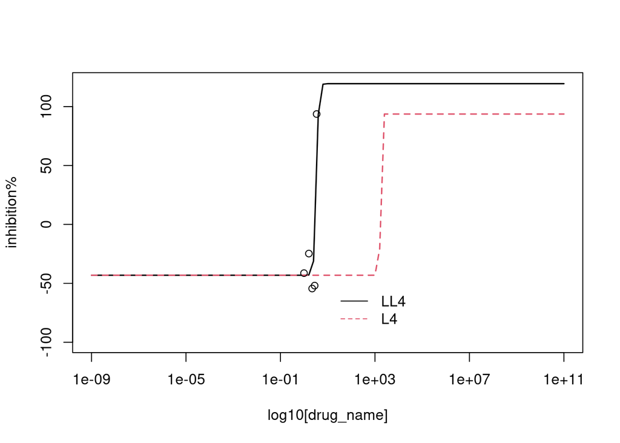

```r
library(grDevices)
LL4_coefs <- coef(LL4_fit)
L4_coefs <- coef(L4_fit)
cols <- palette(rainbow(2))
plot(NULL, xlim = c(10e-10, 10e10), ylim = c(-100, 120),
     ylab = paste("inhibition%"),
     xlab = paste0("log10[", "drug_name", "]"), log = "x")
## Plot LL.4
curve(
        LL4_coefs[2] + (
            LL4_coefs[3] - LL4_coefs[2]
        ) / (
            1 + exp(
                LL4_coefs[1] * (log(x) - log( log10(LL4_coefs[4]) ))
            )
        )
    , from = 10e-10, to = 10e10, add = TRUE, col = cols[1], lwd = 1.5, lty = 1
)
## Plot L.4
curve(
        L4_coefs[2] + (
            L4_coefs[3] - LL4_coefs[2]
        ) / (
            1 + exp(
                L4_coefs[1] * (x - (L4_coefs[4]))
            )
        )
    , from = 10e-10, to = 10e10, add = TRUE, col = cols[2], lwd = 1.5, lty = 2
)
points(x = log10(drug_response$conc),
       y = drug_response$effect)
legend(10, -50,
       legend = c("LL4", "L4"),
       col = cols,
       lty = c(1, 2),
       box.lty = 0
)
```

Note that it’s difficult to plot these two curves on the same scale of log-10 transformed $x$ for comparison, since $x$ were fitted on different scales ($\operatorname{\ln\left(x\right)}$ vs $x$). We will go into further details about why in the next section, as $L.4$ completely replaced $LL.4$ in 2-way curve fitting.

# 2-way Curve Fitting